# time series project

Xiang Liu

November 27, 2014

# Data Information

### > **Data source**: [TN Federal Reserve Bank](http://research.stlouisfed.org/fred2/data/SMU47000006500000003.txt)

### > **Variable**: Average Hourly Earnings of All Employees: Education and Health Services in Tennessee

### > **Monthly Data**: 2007.1 - 2014.9 (93 monthly observations and roughly 7 year statistics)

# Time Series Plot of Original Data

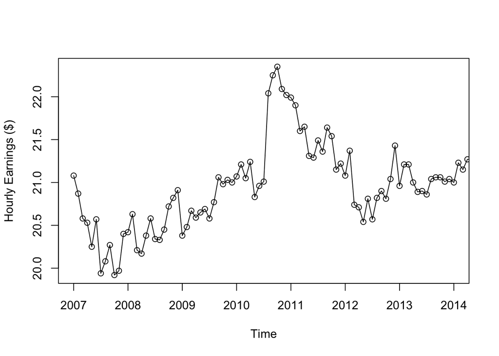

```r
library(RCurl)
URL="http://research.stlouisfed.org/fred2/data/SMU47000006500000003.txt"
pay=getURL(URL)
pay.ts=read.table(textConnection(pay),skip=12)[,2]
pay.ts=ts(pay.ts, start=c(2007,1), frequency=12)
ts.plot(pay.ts,main="", xlim=c(2007,2014), ylab='Hourly Earnings ($)', type='o')
```

```r
# Average Hourly Earnings of All Employees: Education and Health Services in Tennessee
```

### > Clearly, the mean does not remain constant which indicates that this series is nonstationary.

### > My curiosity is why there is a sudden jump in between 2010 and 2011. Is there any policy about education and health service made by then? will this pattern appear again in the future? and find an Arima model to fit the data and do excellent job in forecasting.

# Check Stationary Process

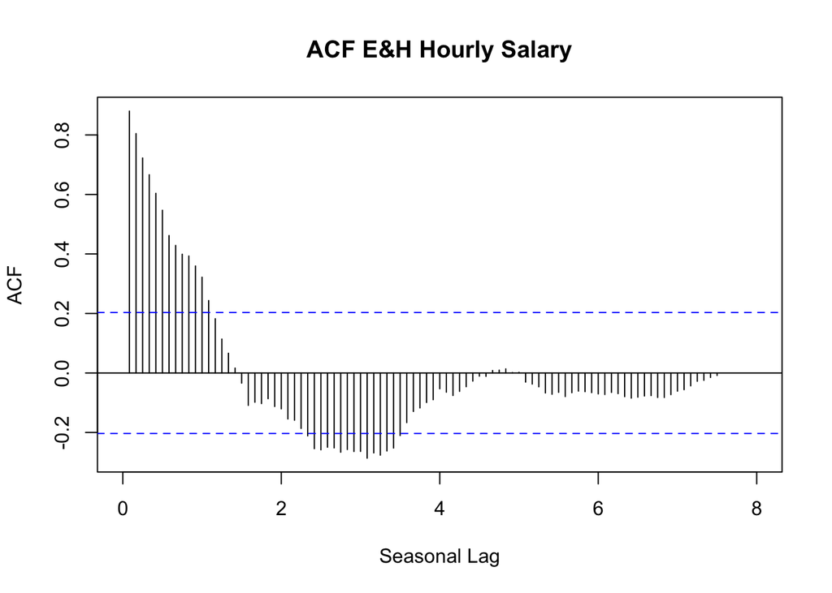

```r
library(TSA)
acf(pay.ts,lag=90,main="ACF E&H Hourly Salary", xlim=c(0,8),xlab='Seasonal Lag')
```

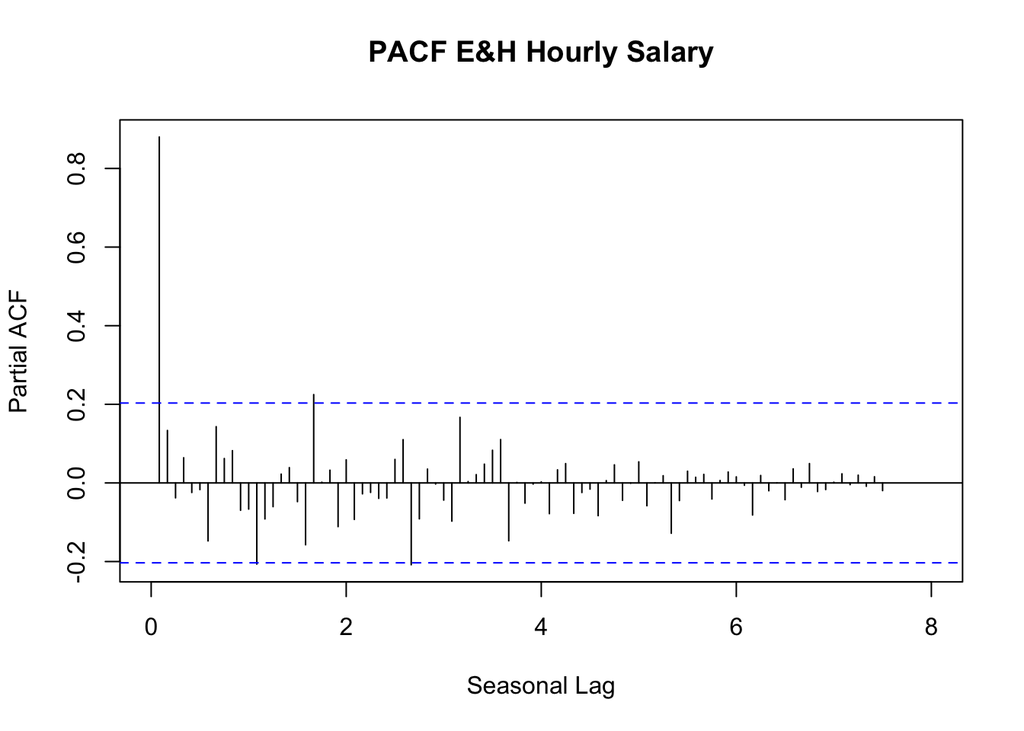

```r
pacf(pay.ts,lag=90,main="PACF E&H Hourly Salary", xlim=c(0,8),xlab='Seasonal Lag')
```

```r
library(tseries)
adf.test(pay.ts)
```

```
    Augmented Dickey-Fuller Test

data:  pay.ts
Dickey-Fuller = -2.0272, Lag order = 4, p-value = 0.5651
alternative hypothesis: stationary
```

### > Both ACF and PACF plots show signs that the E&H Salary data is nonstationary. This is suggested by a gradually trails off in the ACF and a very large at lag 1 in the PACF.

### > Amented Dickey-Fuller test also supports my thought. It’s not stationary as the p-value is higher than 0.05. “Non-stationary” hypothesis cannot be rejected.

# Analyzing Detrended Data

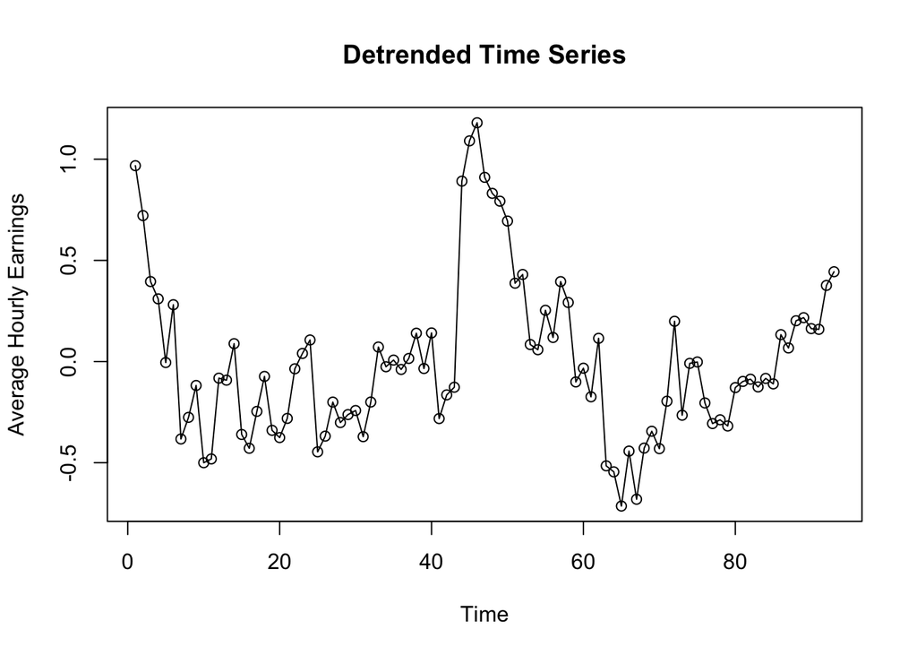

```r
library(dynlm)
t=time(pay.ts)
fit = lm(pay.ts ~ t + I(t^2) + I(t^3))
pay.detrend=fit$resid
plot(pay.detrend,type="o",ylab="Average Hourly Earnings",xlab="Time",main="Detrended Time Series")
```

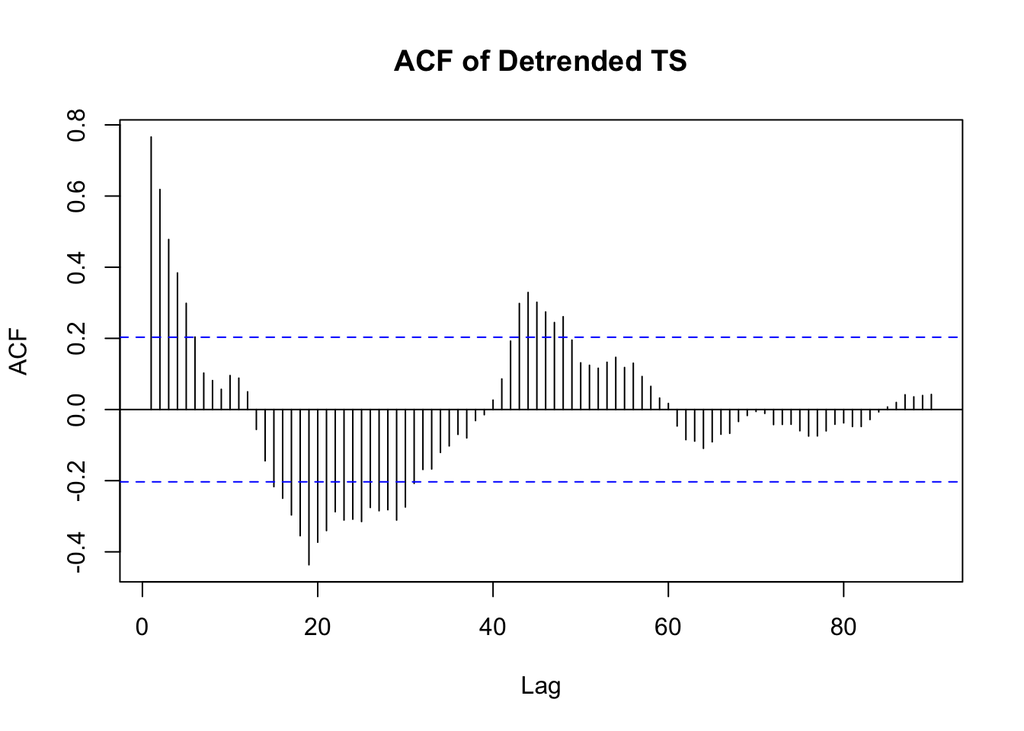

```r
acf(pay.detrend,lag=90,main="ACF of Detrended TS")
```

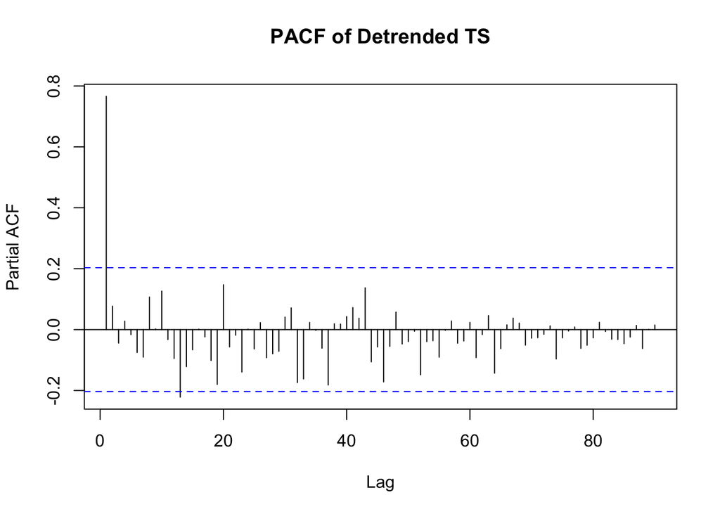

```r
pacf(pay.detrend,lag=90,main="PACF of Detrended TS")
```

```r
adf.test(pay.detrend)
```

```
    Augmented Dickey-Fuller Test

data:  pay.detrend
Dickey-Fuller = -2.4277, Lag order = 4, p-value = 0.3999
alternative hypothesis: stationary
```

### > Both the ACF and PACF plots indicate the detrended time series doesn’t make to be stationary.

### > The ACF still slowly decreases and the PACF is still very large at lag 1. Combined with conclusion draw from Augmented Dickey-Fuller test, simply detrending the series isn’t enough to turn the series into a stationary process.

# Other Transformation

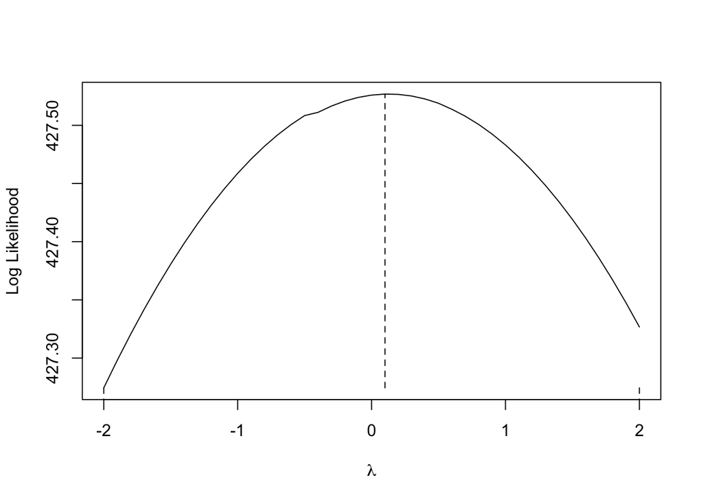

```r
BoxCox.ar(pay.ts)
```

### > Since the 95% confidence interval include between -2 and 2, it suggests that the data isn’t necessary to be transformed.

# 1st Order Differencing

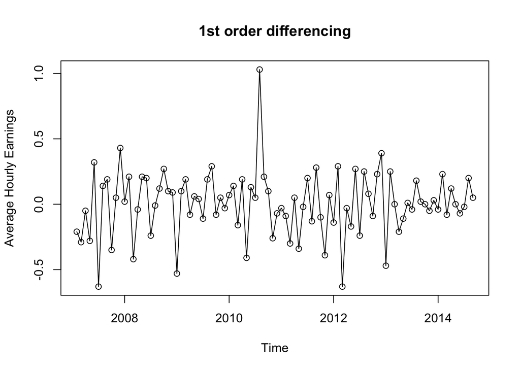

```r
plot(diff(pay.ts),main="1st order differencing", ylab='Average Hourly Earnings', type='o')
```

```r
adf.test(diff(pay.ts))
```

```
    Augmented Dickey-Fuller Test

data:  diff(pay.ts)
Dickey-Fuller = -4.5942, Lag order = 4, p-value = 0.01
alternative hypothesis: stationary
```

### > After 1st order differencing, the time series plot seem to be stationary. The mean mean keeps to be constant over time and there is a little volatility in between 2010 and 2011 (my question)

# Seasonal Order Differencing

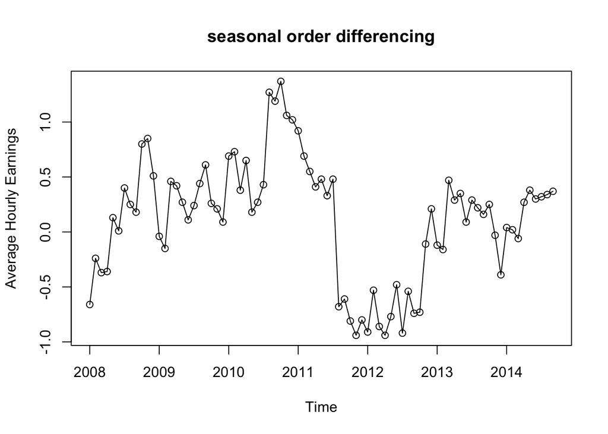

```r
plot(diff(pay.ts,lag=12),main="seasonal order differencing",
     ylab='Average Hourly Earnings', type='o')
```

```r
adf.test(diff(pay.ts,lag=12))
```

```
    Augmented Dickey-Fuller Test

data:  diff(pay.ts, lag = 12)
Dickey-Fuller = -1.9341, Lag order = 4, p-value = 0.6027
alternative hypothesis: stationary
```

### > After seasonal order differencing, the time series plot still looks non-stationary. It seems to be unnecessary to take seasonal order differencing as also supported by the Augmented Dickey-Fuller test.

# Time Series Plot of Seasonality

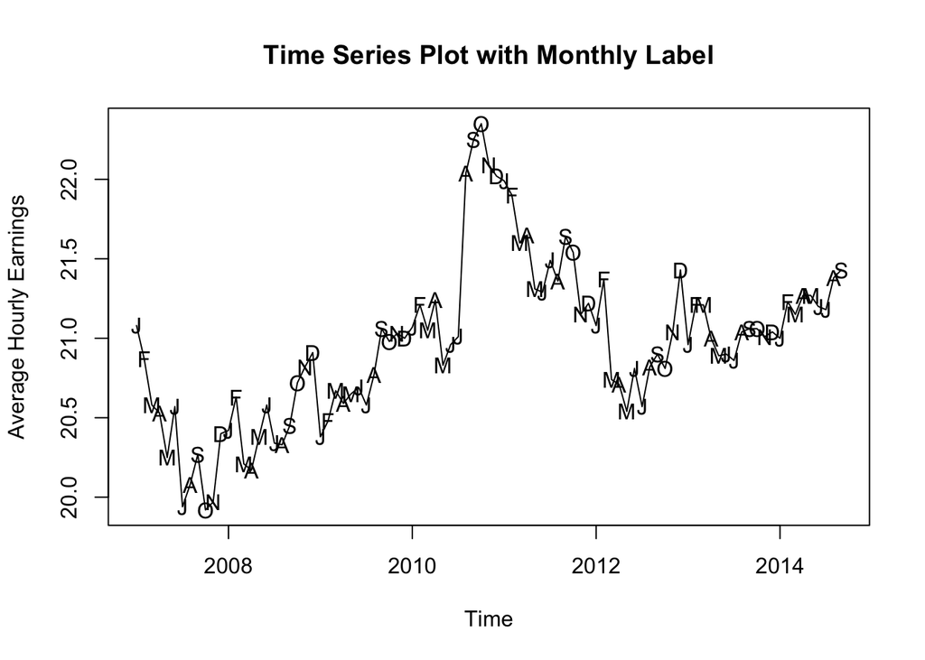

```r
plot(pay.ts,main="Time Series Plot with Monthly Label", ylab='Average Hourly Earnings')
points(y=pay.ts,x=time(pay.ts),pch=as.vector(season(pay.ts)))
```

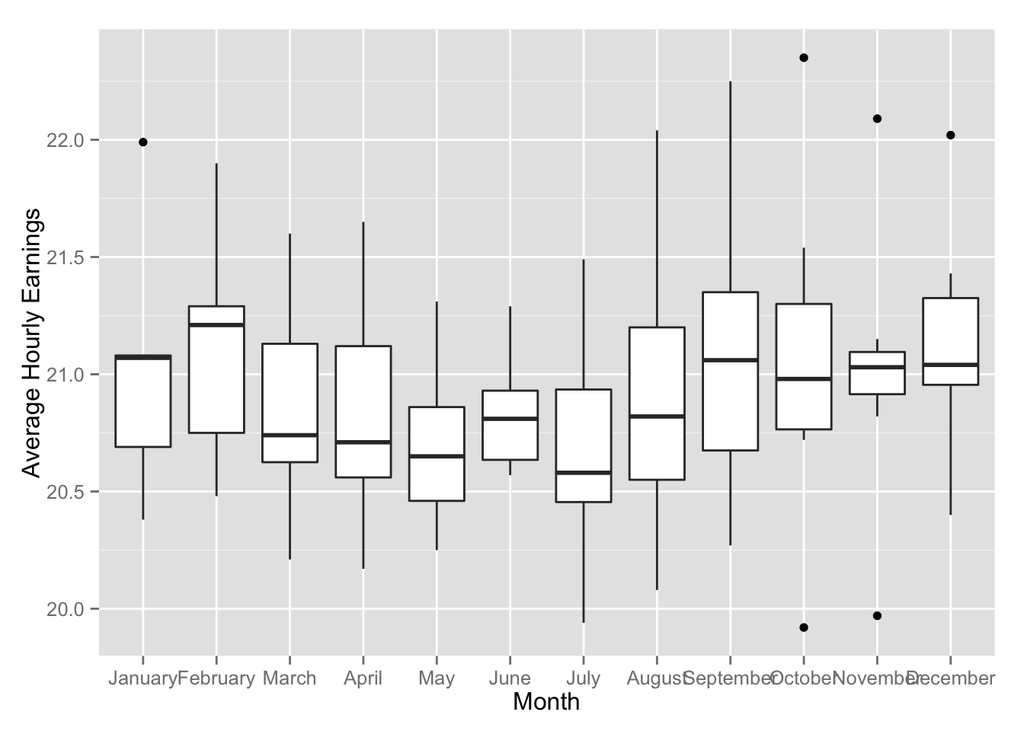

```r
library(ggplot2)
month_range = factor(month.name,levels=month.name)
measure = pay.ts[1:84]
mydata = data.frame(month_range, measure)
ggplot(mydata, aes(x=factor(month_range), y=measure)) +
  geom_boxplot(aes(fill=measure)) + xlab("Month") + ylab("Average Hourly Earnings") +
  scale_fill_discrete(name = "Measure")
```

# Model Specification

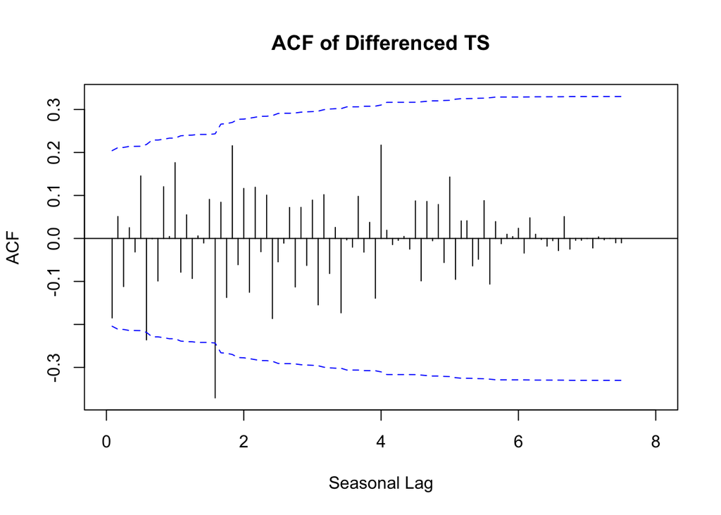

```r
pay.df=diff(pay.ts)
acf(pay.df,lag=90,main="ACF of Differenced TS", xlim=c(0,8),
    xlab='Seasonal Lag', ci.type = "ma")
```

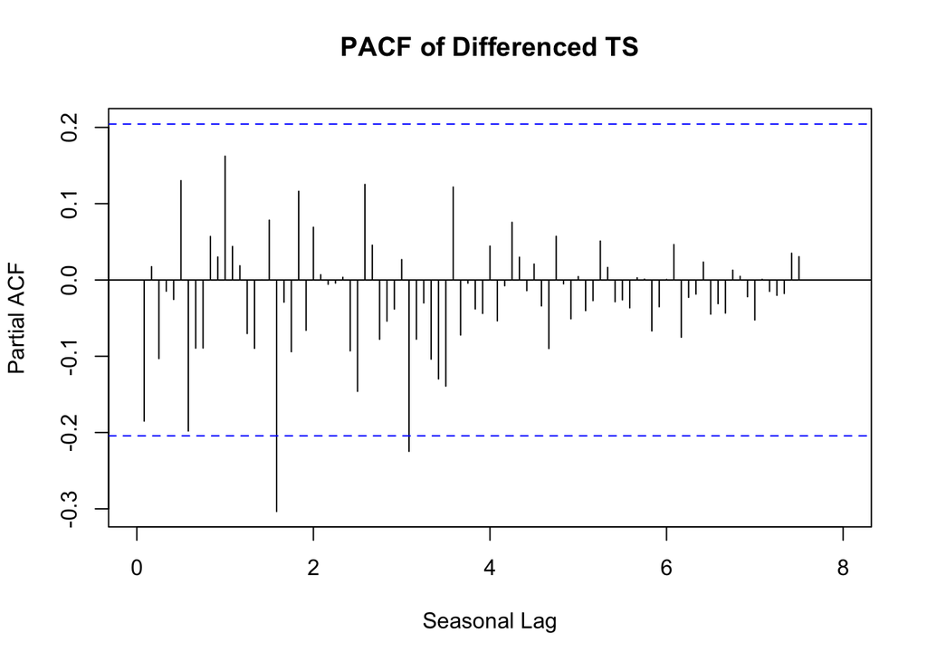

```r
pacf(pay.df,lag=90,main="PACF of Differenced TS", xlim=c(0,8),xlab='Seasonal Lag')
```

### > Using conservative confidence interval to plot ACF, the acf suggests a possible seasonal MA(0 or 1) and the PACF indicates a possible seasonal AR(0 or 1) model

### > Also the lag 1 in PACF almost reach signficance, which suggests me to consider AR(1) nonseasonal model.

### > What’s odd is the sike isn’t exactly on the seasonal lag (question)

# Model Specification

```r
graphics.off()
rm(ls=x)
rm(ls=y)
rm(ls=z)
library(astsa)
x=numeric(18)
z=numeric(18)
y=matrix(,18,5)
n=1
for (a in 0:1) {
  for (b in 0:2 ) {
    for (c in 0:2) {
      x[n]=sarima(pay.ts, a, 1, 0, b, 0, c, 12, detail=F, no.constant = T)$AIC
      z[n]=sarima(pay.ts, a, 1, 0, b, 0, c, 12, detail=F, no.constant = T)$BIC
      y[n,]=c(a,b,c,x[n],z[n])
      n=n+1
      }
    }
  }
rownames(y)=c(1:18)
colnames(y)=c('AR(p)', 'SAR(P)', 'SMA(Q)', 'AIC','BIC')
print(y)
```

```
   AR(p) SAR(P) SMA(Q)       AIC       BIC
1      0      0      0 -1.826375 -2.826375
2      0      0      1 -1.837187 -2.809954
3      0      0      2 -1.828474 -2.774010
4      0      1      0 -1.844929 -2.817697
5      0      1      1 -2.003494 -2.949029
6      0      1      2 -1.996721 -2.915024
7      0      2      0 -1.837379 -2.782914
8      0      2      1 -1.999276 -2.917579
9      0      2      2 -2.001515 -2.892586
10     1      0      0 -1.839829 -2.812597
11     1      0      1 -1.851933 -2.797468
12     1      0      2 -1.838481 -2.756784
13     1      1      0 -1.857477 -2.803013
14     1      1      1 -1.993796 -2.912099
15     1      1      2 -1.967801 -2.858872
16     1      2      0 -1.841469 -2.759772
17     1      2      1 -1.849383 -2.740454
18     1      2      2 -1.927462 -2.791301
```

### > According to AIC and BIC, the best model is SARMA(1,1) model with 1st order differencing. Let’s do time series diagnose.

# Model Diagnose

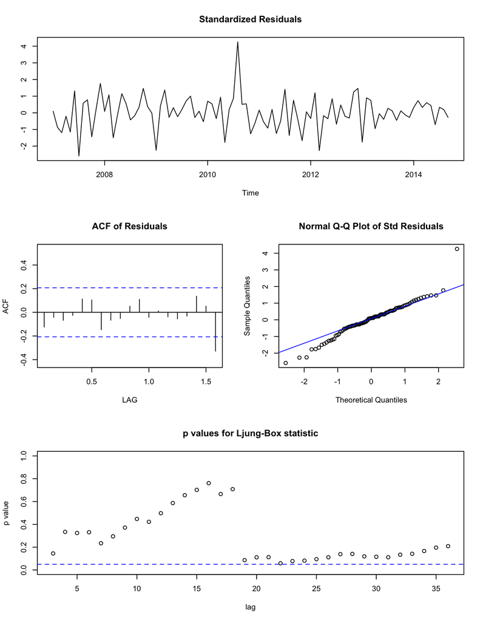

```
Call:
stats::arima(x = xdata, order = c(p, d, q), seasonal = list(order = c(P, D,
    Q), period = S), include.mean = !no.constant, optim.control = list(trace = trc,
    REPORT = 1, reltol = tol))

Coefficients:
        sar1     sma1
      0.9977  -0.9645
s.e.  0.0219   0.1700

sigma^2 estimated as 0.04752:  log likelihood = 4.14,  aic = -2.28
```

```r
(pay.m1=sarima(pay.ts, 0,1,0,1,0,1,12, details = F,no.constant = T)$fit)
```

# Model Selection

# Model Comparison

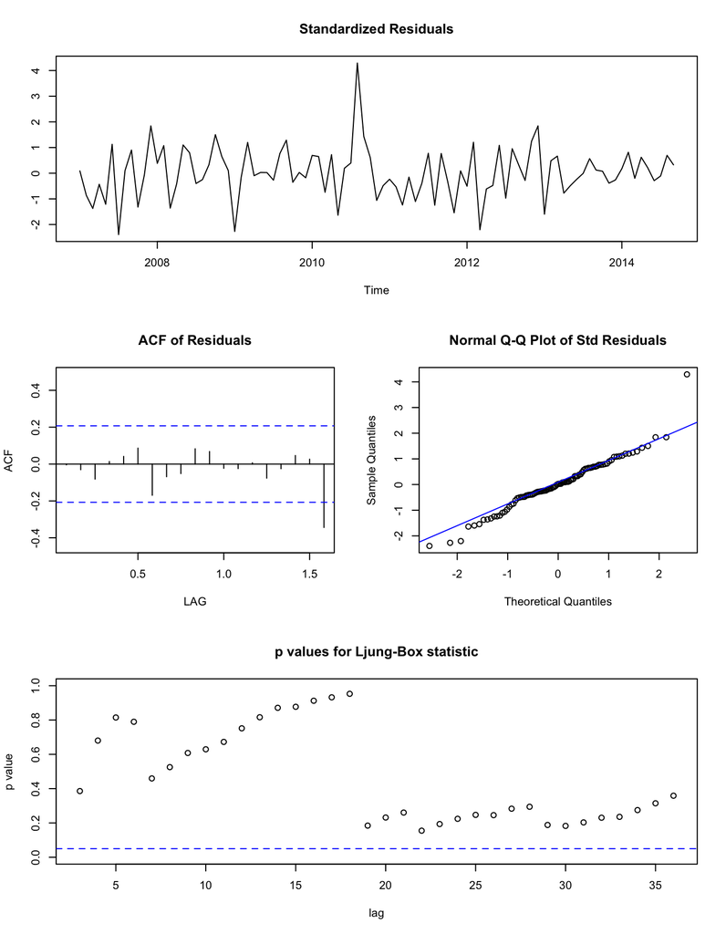

```
Call:
stats::arima(x = xdata, order = c(p, d, q), seasonal = list(order = c(P, D,
    Q), period = S), include.mean = !no.constant, optim.control = list(trace = trc,
    REPORT = 1, reltol = tol))

Coefficients:
          ar1    sar1
      -0.1825  0.1914
s.e.   0.1026  0.1062

sigma^2 estimated as 0.055:  log likelihood = 2.64,  aic = 0.72
```

```r
(pay.m2=sarima(pay.ts, 1,1,0,1,0,0,12, details = F,no.constant = T)$fit)
```

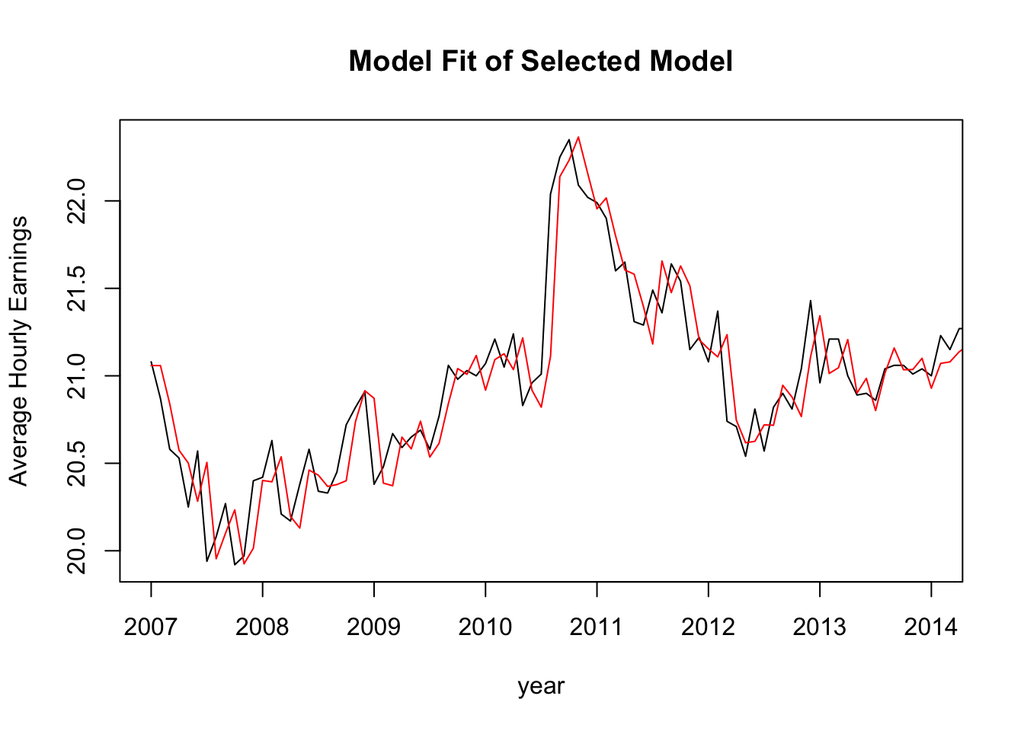

```r
pay.fit2=pay.ts-resid(pay.m2)
pay.fit=pay.ts-resid(pay.m1)
require(graphics)
ts.plot(pay.ts, pay.fit, gpars=list(xlab="year", xlim= c(2007, 2014), ylab="Average Hourly Earnings"),
        col=c("black","red"), main= "Model Fit of Selected Model")
```

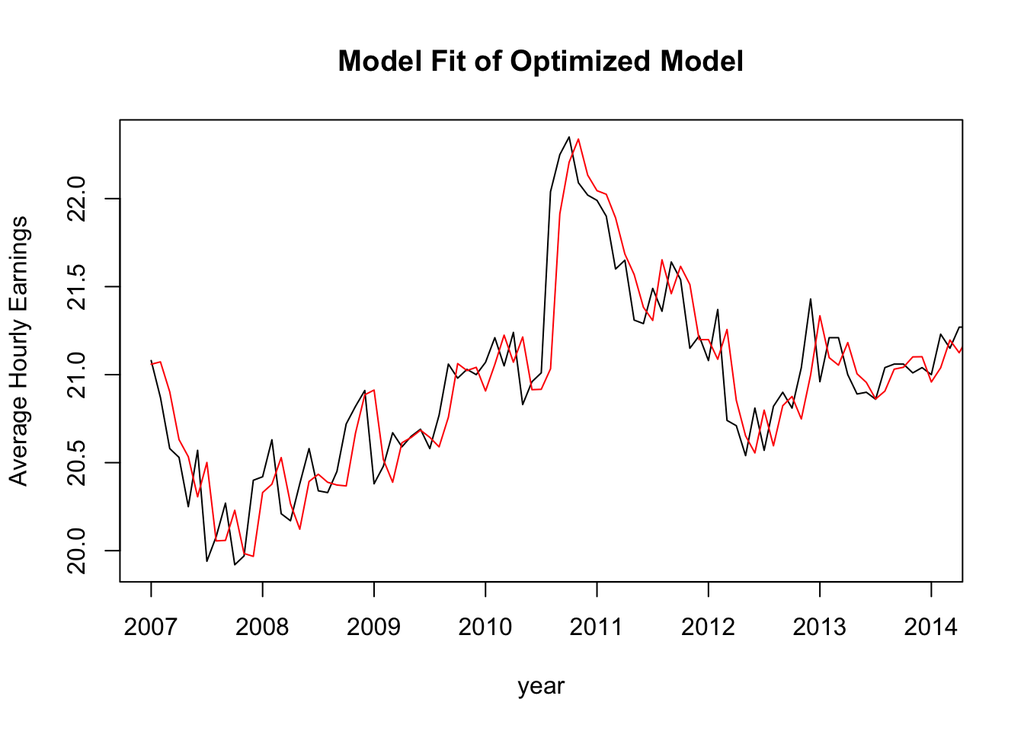

```r
ts.plot(pay.ts,pay.fit2, gpars=list(xlab="year", xlim= c(2007, 2014), ylab="Average Hourly Earnings"),
        col=c("black","red"), main= "Model Fit of Optimized Model")
```

```r
ifelse(sum(resid(pay.m2$fit)^2) > sum(resid(pay.m1$fit)^2),
       "Selected Model Has Smaller Sum of Sigma Square",
       "Optimized Model Has Smaller Sum of Sigma Square")
```

[output not shown]

# Model Forecast

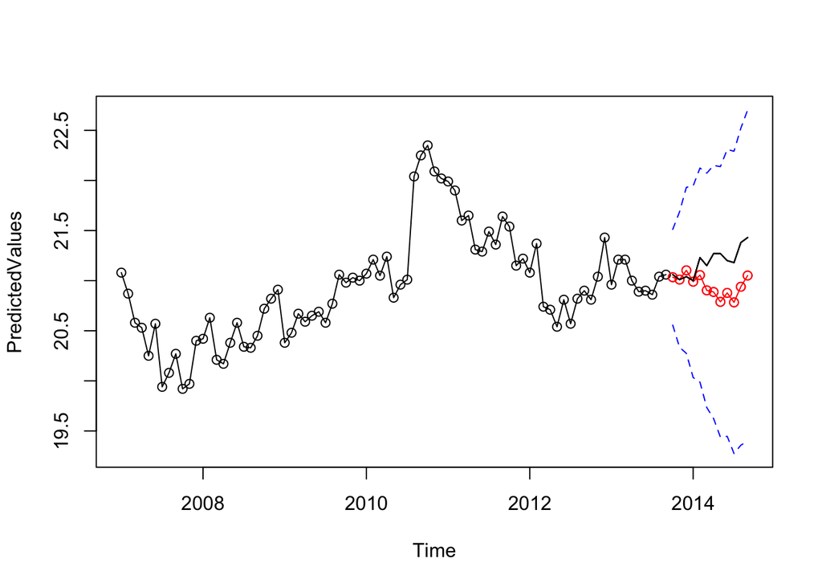

```r
library(forecast)
h=12
n = length(pay.ts) - h
pay1 = ts(pay.ts[1:n],start=c(2007,1), frequency=12)
pay2 = ts(pay.ts[(n+1):length(pay.ts)], end =c(2014,9), frequency=12)
PredictedValues=pay1
pay1.pr = sarima.for(PredictedValues, n.ahead = h, 0,1,0,1,0,1,12,no.constant = T)
lines(pay2);lines(pay2);lines(pay2);lines(pay2)
abline(v=n+.5)
```

```r
error=pay2 - pay1.pr$pred
predictions = pay1.pr$pred
se = pay1.pr$se
actual=pay2
cbind(predictions,se,actual,error)
```

```
         predictions        se actual         error
Oct 2013    21.03390 0.2391379  21.06  0.0260982597
Nov 2013    21.01079 0.3381920  21.01 -0.0007928368
Dec 2013    21.10276 0.4141989  21.04 -0.0627635653
Jan 2014    20.98957 0.4782757  21.00  0.0104329191
Feb 2014    21.05544 0.5342643  21.23  0.1745609764
Mar 2014    20.90329 0.5849179  21.15  0.2467062701
Apr 2014    20.88696 0.6315217  21.27  0.3830377583
May 2014    20.78840 0.6749150  21.27  0.4816017468
Jun 2014    20.87776 0.7156822  21.20  0.3222432674
Jul 2014    20.78323 0.7542490  21.18  0.3967654365
Aug 2014    20.93915 0.7909376  21.38  0.4408535340
Sep 2014    21.05118 0.8259981  21.43  0.3788195993
```

### > Using a built-up model to predict 12 month data approaching the future, the graph is good at forecasting the future values of the E&H hourly salary. All predicted values are within 95% confidence interval.

### > However, the error tends to go higher as it progresses to the future. And the model consistently underestimate the realistic value.